# Teste Cientista de dados - ELEFLOW

# Parte 1 - Visualização de dados

## Introdução

O banco de dados utilizado apresenta informações referentes à 16598 títulos de vídeo games. A seguir, pode-se visualizar os 5 primeiros lugares do rank.

| Rank | Name | Platform | Year | Genre | Publisher | NA_Sales | EU_Sales | JP_Sales | Other_Sales | Global_Sales |
| --- | --- | --- | --- | --- | --- | --- | --- | --- | --- | --- |
| 1 | Wii Sports | Wii | 2006 | Sports | Nintendo | 41.49 | 29.02 | 3.77 | 8.46 | 82.74 |
| 2 | Super Mario Bros. | NES | 1985 | Platform | Nintendo | 29.08 | 3.58 | 6.81 | 0.77 | 40.24 |
| 3 | Mario Kart Wii | Wii | 2008 | Racing | Nintendo | 15.85 | 12.88 | 3.79 | 3.31 | 35.82 |
| 4 | Wii Sports Resort | Wii | 2009 | Sports | Nintendo | 15.75 | 11.01 | 3.28 | 2.96 | 33.00 |
| 5 | Pokemon Red/Pokemon Blue | GB | 1996 | Role-Playing | Nintendo | 11.27 | 8.89 | 10.22 | 1.00 | 31.37 |

## A) Gêneros mais populares

O Gráfico de barras a seguir apresenta os gêneros mais populares entre os 150 primeiros títulos do rank. Pode-ser perceber que há 11 gêneros diferentes entre os títulos mais vendidos, sendo que os 3 gêneros foram “shooter”, “action” e “role-playing”, respectivamente.

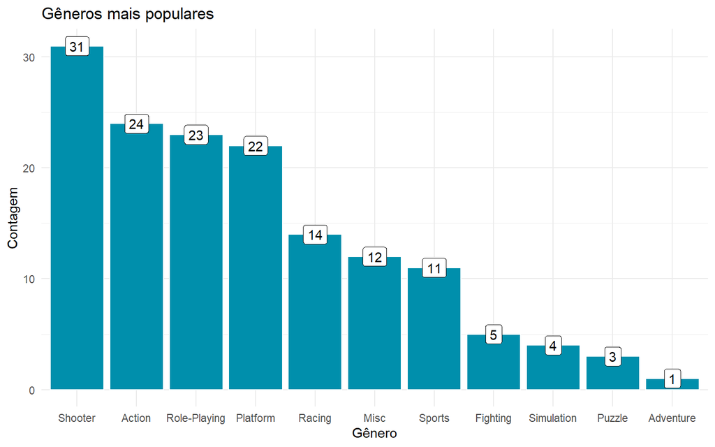

## B) Retrospectiva de vendas da Nintendo

Como pode ser visto no gráfico a seguir, no banco de dados disponibilizado consta que a Nintendo publicou 116 desde 2012, sendo que o pico de lançamentos foi o ano de 2015 e o último jogo foi publicado em 2016.

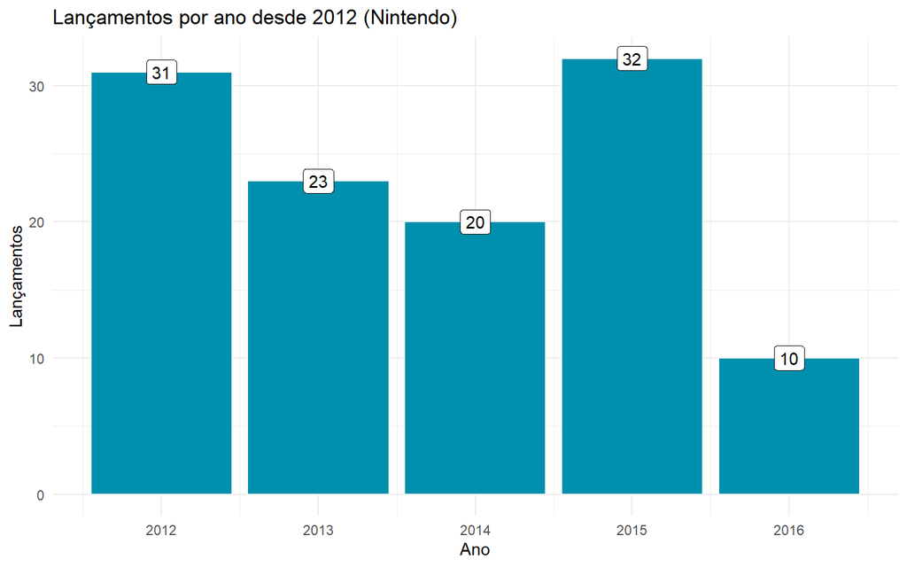

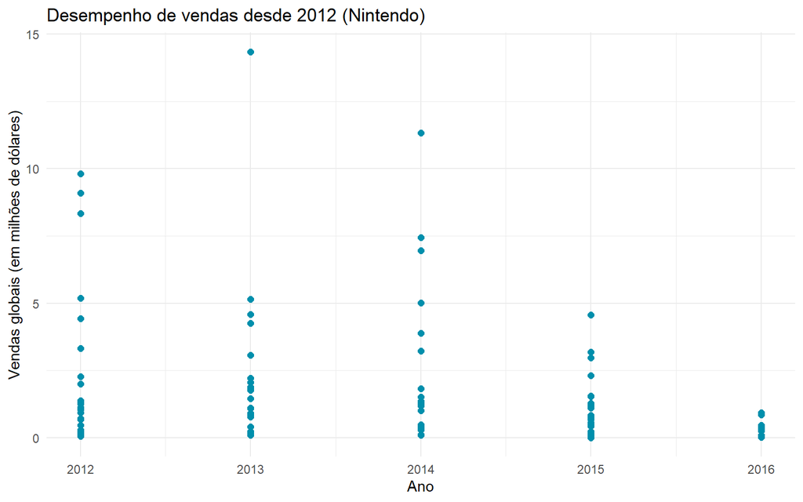

Ao realizar o teste de correlação de Pearson, conclui-se que, à um nível de significância de 5%, que a correlação entre o ano de lançamento e as vendas globais foi de aproximadamente -0.205, isto é, há evidências estatísticas para se dizer que as vendas da Nintendo diminuiram nos últimos anos.

```
##
##  Pearson's product-moment correlation
##
## data:  data_nintendo_latest$Year and data_nintendo_latest$Global_Sales
## t = -2.2399, df = 114, p-value = 0.02703
## alternative hypothesis: true correlation is not equal to 0
## 95 percent confidence interval:
##  -0.37364941 -0.02389765
## sample estimates:
##        cor
## -0.2053197
```

Por fim, a tabela a seguir apresenta os títulos da Nintendo que se destacaram e alcançaram mais que 5 milhões de dólares nas vendas globais.

| Rank | Name | Platform | Year | Genre | Publisher | NA_Sales | EU_Sales | JP_Sales | Other_Sales | Global_Sales |
| --- | --- | --- | --- | --- | --- | --- | --- | --- | --- | --- |
| 33 | Pokemon X/Pokemon Y | 3DS | 2013 | Role-Playing | Nintendo | 5.17 | 4.05 | 4.34 | 0.79 | 14.35 |
| 50 | Pokemon Omega Ruby/Pokemon Alpha Sapphire | 3DS | 2014 | Role-Playing | Nintendo | 4.23 | 3.37 | 3.08 | 0.65 | 11.33 |
| 65 | New Super Mario Bros. 2 | 3DS | 2012 | Platform | Nintendo | 3.66 | 3.07 | 2.47 | 0.63 | 9.82 |
| 74 | Animal Crossing: New Leaf | 3DS | 2012 | Simulation | Nintendo | 2.01 | 2.32 | 4.36 | 0.41 | 9.09 |
| 82 | Pokemon Black 2/Pokemon White 2 | DS | 2012 | Role-Playing | Nintendo | 2.91 | 1.86 | 3.14 | 0.43 | 8.33 |
| 98 | Super Smash Bros. for Wii U and 3DS | 3DS | 2014 | Fighting | Nintendo | 3.24 | 1.35 | 2.42 | 0.43 | 7.45 |
| 109 | Mario Kart 8 | WiiU | 2014 | Racing | Nintendo | 3.13 | 2.07 | 1.27 | 0.49 | 6.96 |
| 184 | New Super Mario Bros. U | WiiU | 2012 | Platform | Nintendo | 2.32 | 1.30 | 1.27 | 0.31 | 5.19 |
| 189 | Tomodachi Life | 3DS | 2013 | Simulation | Nintendo | 0.96 | 2.02 | 1.89 | 0.28 | 5.15 |
| 204 | Super Smash Bros. for Wii U and 3DS | WiiU | 2014 | Fighting | Nintendo | 2.59 | 1.06 | 0.80 | 0.57 | 5.02 |

## C) Maiores “Publishers” em vendas nos Estados Unidos

A seguir, é apresentado a quantidade de vendas das 5 maiores Publishers dos estados Unidos, sendo que a que apresentou maior quantidade de vendas foi a Nintendo.

| Publisher | Vendas |
| --- | --- |
| Nintendo | 816.87 |
| Electronic Arts | 595.07 |
| Activision | 429.70 |
| Sony Computer Entertainment | 265.22 |
| Ubisoft | 253.43 |

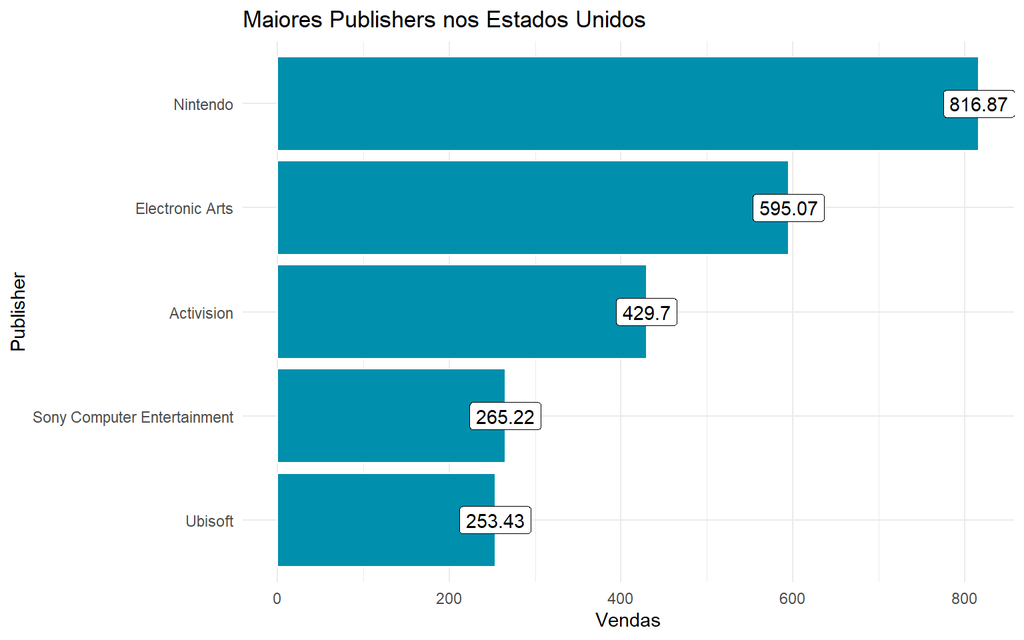

# Parte 2 - Machine Learning

## A) Aprendizado supervisionado X não supervisionado

O aprendizado de máquina supervisionado visa a criação de um modelo preditivo via treinamento através de um banco de dados “completo”, isto é, que possui tanto as variáveis dependentes do modelo quanto a variável resposta. Sendo assim, o objetivo principal de um modelo feito através do aprendizado supervisionado é conseguir categorizar ou identificar corretamente um evento, baseado em exemplos vistos anteriormente, como por exemplo um modelo para diagnóstico de determinada doença baseado em informações de um paciente. Alguns exemplos de algoritmos supervisionado são o KNN, que irá classificar a observação de acordo com os “K vizinhos mais próximos”, ou até mesmo modelos de regressão, em que o interesse é a predição de um valor contínuo.

Por sua vez, o aprendizado de máquina não supervisionado consiste em agrupar as observações baseadas em suas características, ou seja, nesse caso não existe um valor “certo” a ser predito, mas sim há o interesse de criar grupos para os valores observados, como um modelo que pretende classificar jogadores de futebol baseado em suas performances ao longo da temporada. Alguns exemplos de algoritmos não supervisionado são o K-means e o modelo de agrupamento hierárquico.

## B) Analisando matrizes de confusão

A tabela a seguir apresenta a acurácia, especificidade e sensitividade de cada uma das matrizes.

|  | Acurácia | Especificidade | Sensitividade |
| --- | --- | --- | --- |
| Matriz 1 | 0.902 | 0.948 | 0.837 |
| Matriz 2 | 0.839 | 0.912 | 0.771 |

Como pode ser visto na tabela acima, a matriz 1 possui maiores valores para acurácia, especificidade e sensitividade, ou seja, ela foi capaz de prever mais resultados corretamente, além de possuir um melhor desempenho em realmente identificar valores negativos e posivitos, se comparado com a matriz 2. Portanto, pode-se considerar o modelo 1 como o melhor ajustado.

# Desafio

## Introdução

A fim de prever a nota de filmes baseado em suas características, foi fornecido um banco de dados com 6234 obersvações e 12 variáveis.

Visando limpar o banco de dados para realizar a modelagem, foram filtrados somente os títulos que são filmes e de fato possuem alguma nota (rating > 0), além de remover as variáveis `show_id`, `director`, `description`, `title` e `date_added`. Além disso, a variável `duration` foi manipulada para ser tratada como número e as variáveis `cast`, `country` e `listed_in` foram substitudas por `n_cast`, `n_country` e `n_listed_in`, representando o número de pessoas no elenco, o número de países em que o título está disponível e o número de categorias, respsectivamente.

Além disso, sabendo da importância do mercado norte americano, foi adicionada um variável *dummy* `is_in_usa`, representando se o título está disponível nos Estados Unidos.

Deste modo, após manipulações, o banco limpo apresenta 4085 observações e 7 variáveis.

| release_year | rating | duration | n_cast | n_country | n_listed_in | is_in_usa |
| --- | --- | --- | --- | --- | --- | --- |
| 2019 | 41 | 90 | 10 | 4 | 2 | TRUE |
| 2016 | 52 | 94 | 1 | 1 | 1 | FALSE |
| 2017 | 57 | 99 | 12 | 1 | 1 | TRUE |
| 2014 | 61 | 110 | 9 | 4 | 3 | TRUE |
| 2017 | 49 | 60 | 1 | 1 | 1 | FALSE |
| 2014 | 56 | 90 | 11 | 4 | 2 | TRUE |

## Análise descritiva

Fazendo uma breve análise do banco de dados limpo, obtém-se os seguintes gráficos:

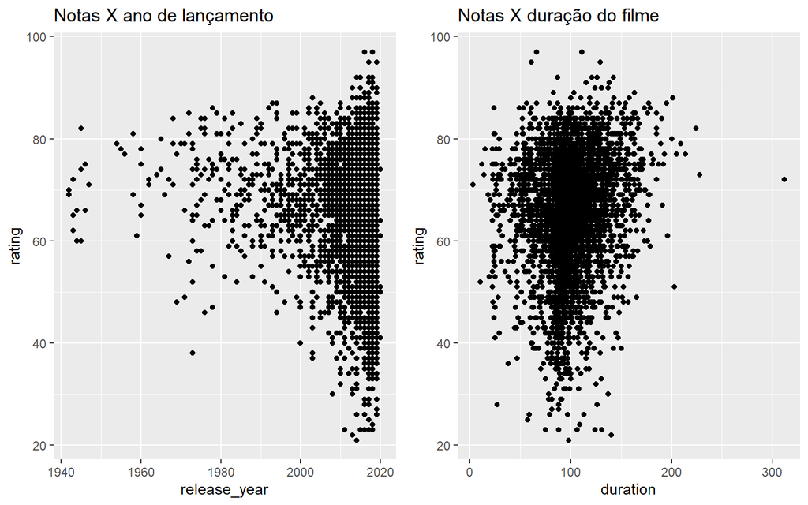

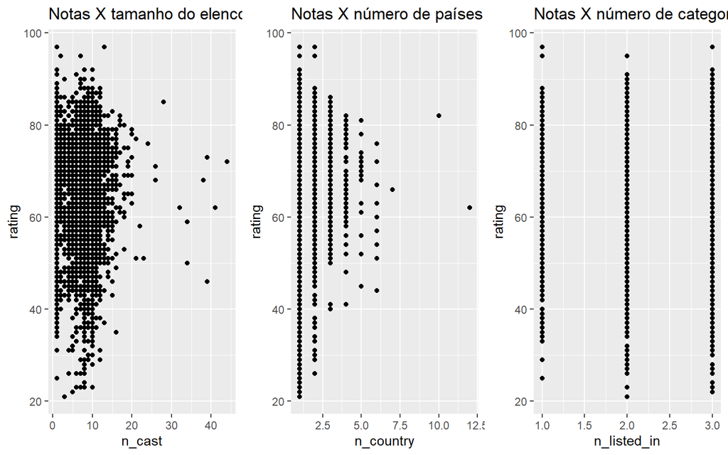

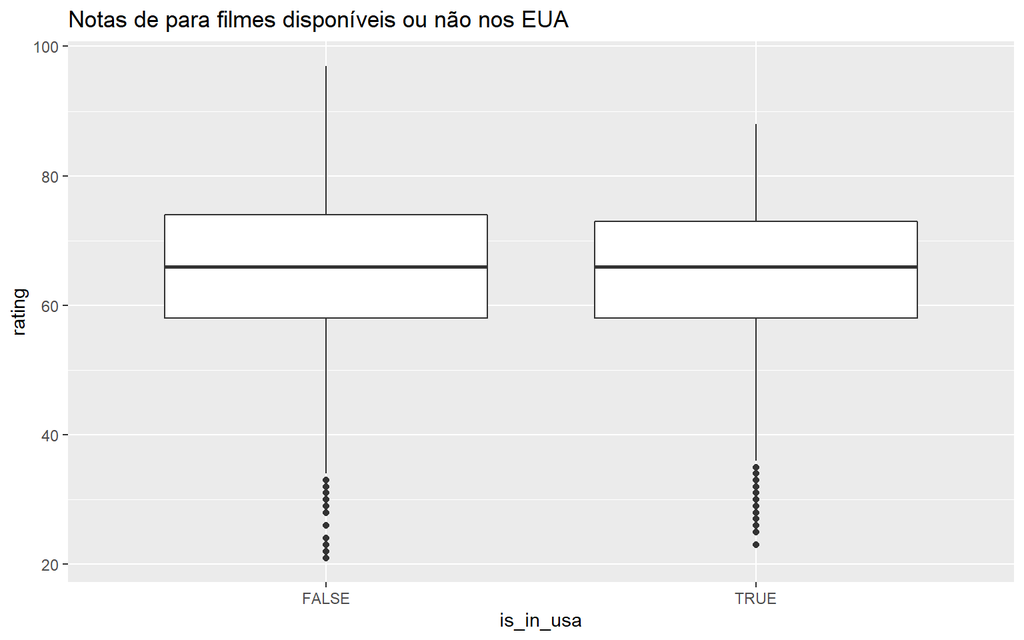

Baseado nos gráficos acima, há indícios de que quanto mais antigo o filme melhor sua classificação, e quanto menor o número de países em que o filme está disponível, melhor sua classificação. As demais variáveis não apresentaram nenhuma relação aparente.

## Modelo de regressão

A fim de prever a nota do filme, que é uma variável quantitativa contínua, será modelado um modelo de regressão, dado que o interesse em questão está na predição de um valor.

```
##
## Call:
## lm(formula = rating ~ ., data = data_netflix_clean)
##
## Residuals:
##     Min      1Q  Median      3Q     Max
## -47.102  -6.440   0.999   7.660  34.253
##
## Coefficients:
##                 Estimate Std. Error t value Pr(>|t|)
## (Intercept)   387.965801  36.254032  10.701  < 2e-16 ***
## release_year   -0.163281   0.017927  -9.108  < 2e-16 ***
## duration        0.086978   0.007302  11.912  < 2e-16 ***
## n_cast         -0.501057   0.044571 -11.242  < 2e-16 ***
## n_country       0.665757   0.236936   2.810  0.00498 **
## n_listed_in    -0.172323   0.265189  -0.650  0.51585
## is_in_usaTRUE   0.188913   0.393617   0.480  0.63129
## ---
## Signif. codes:  0 '***' 0.001 '**' 0.01 '*' 0.05 '.' 0.1 ' ' 1
##
## Residual standard error: 10.89 on 4078 degrees of freedom
## Multiple R-squared:  0.07465,    Adjusted R-squared:  0.07329
## F-statistic: 54.83 on 6 and 4078 DF,  p-value: < 2.2e-16
```

Observando o resultado do primeiro modelo, nota-se que a quantidade de categorias e se o filme está disponível nos Estados Unidos não foram variáveis significativas no modelo, além disso, o valor do $R^2$ ajustado indica que o modelo explica de forma satisfatória somente cerca de 7.33% dos dados. Sendo assim, será feita uma nova modelagem removendo essas variáveis.

```
##
## Call:
## lm(formula = rating ~ ., data = data_netflix_clean2)
##
## Residuals:
##     Min      1Q  Median      3Q     Max
## -47.216  -6.424   0.973   7.663  34.059
##
## Coefficients:
##               Estimate Std. Error t value Pr(>|t|)
## (Intercept)  389.85501   35.81708  10.885  < 2e-16 ***
## release_year  -0.16421    0.01774  -9.256  < 2e-16 ***
## duration       0.08394    0.00667  12.586  < 2e-16 ***
## n_cast        -0.50362    0.04339 -11.608  < 2e-16 ***
## n_country      0.68040    0.23380   2.910  0.00363 **
## ---
## Signif. codes:  0 '***' 0.001 '**' 0.01 '*' 0.05 '.' 0.1 ' ' 1
##
## Residual standard error: 10.89 on 4080 degrees of freedom
## Multiple R-squared:  0.07441,    Adjusted R-squared:  0.07351
## F-statistic:    82 on 4 and 4080 DF,  p-value: < 2.2e-16
```

Após a remoção das variáveis mencionadas, nota-se que as demais permaneceram significativas, entretanto, o valor do $R^2$ aumentou muito pouco.

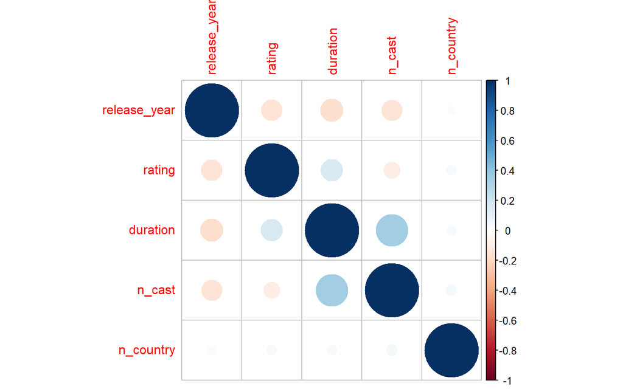

Verificando se há indícios de multicolinearidade entre as variáveis, observa-se que não há nenhuma correlação forte entre elas, o que permite continuar a modelagem sem a necessidade de realizar algum método de redução de variáveis como por exemplo análise de componentes.

Seguindo a análise, o próximo passo é realizar a análise de resíduos para verificar a adequação do modelo.

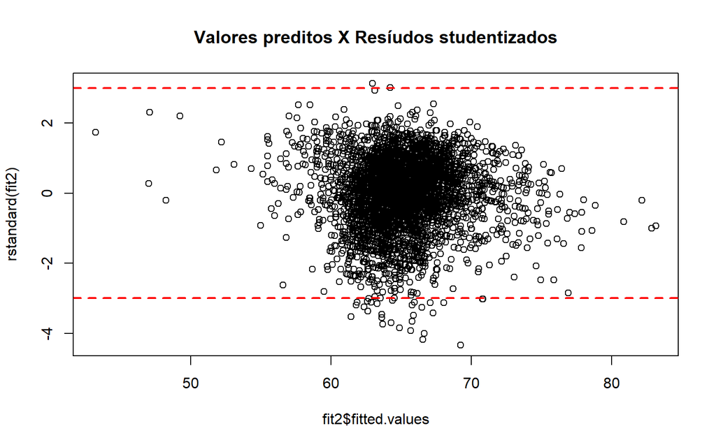

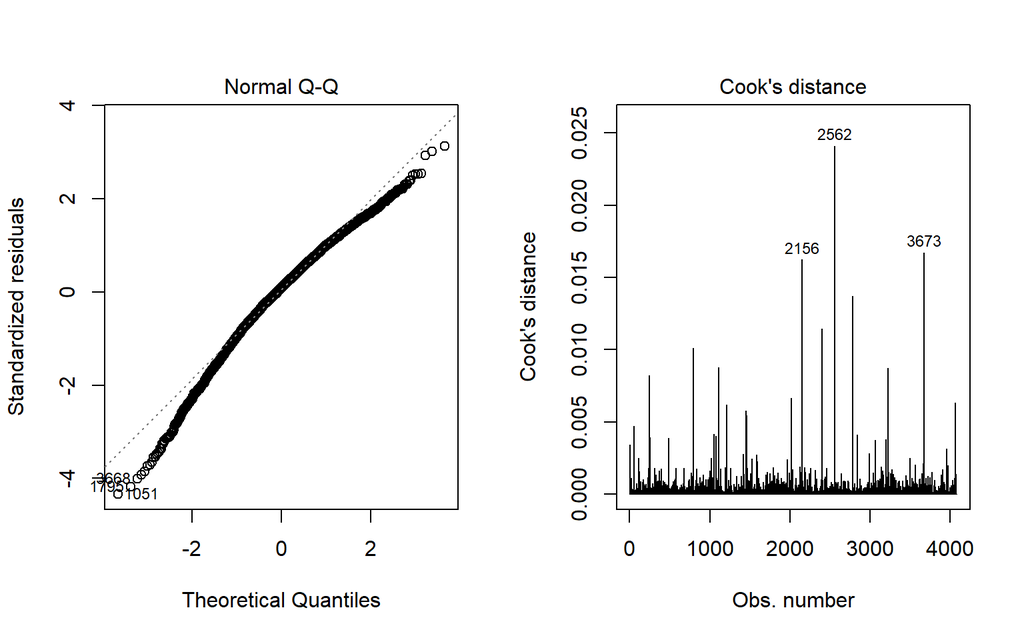

Ao observar os resíduos studentizados, verificar-se que alguns valores acabaram ficando fora da região aceitável. Além disso, o QQ plot apresenta caudas pesadas, o que também mostra indícios de resíudos não normais. Ademais, a distância de Cook também apresenta alguns valores que podem ser possíveis pontos de alavanca, sendo assim, um novo modelo removendo estes valores pode gerar um novo modelo com um melhor resultado.

```
##
## Call:
## lm(formula = rating ~ ., data = data_netflix_clean3)
##
## Residuals:
##     Min      1Q  Median      3Q     Max
## -47.336  -6.384   0.944   7.649  34.171
##
## Coefficients:
##               Estimate Std. Error t value Pr(>|t|)
## (Intercept)  393.20985   35.74364  11.001  < 2e-16 ***
## release_year  -0.16594    0.01770  -9.372  < 2e-16 ***
## duration       0.08593    0.00669  12.846  < 2e-16 ***
## n_cast        -0.54805    0.04465 -12.274  < 2e-16 ***
## n_country      0.86715    0.24248   3.576 0.000353 ***
## ---
## Signif. codes:  0 '***' 0.001 '**' 0.01 '*' 0.05 '.' 0.1 ' ' 1
##
## Residual standard error: 10.86 on 4074 degrees of freedom
## Multiple R-squared:  0.07834,    Adjusted R-squared:  0.07744
## F-statistic: 86.57 on 4 and 4074 DF,  p-value: < 2.2e-16
```

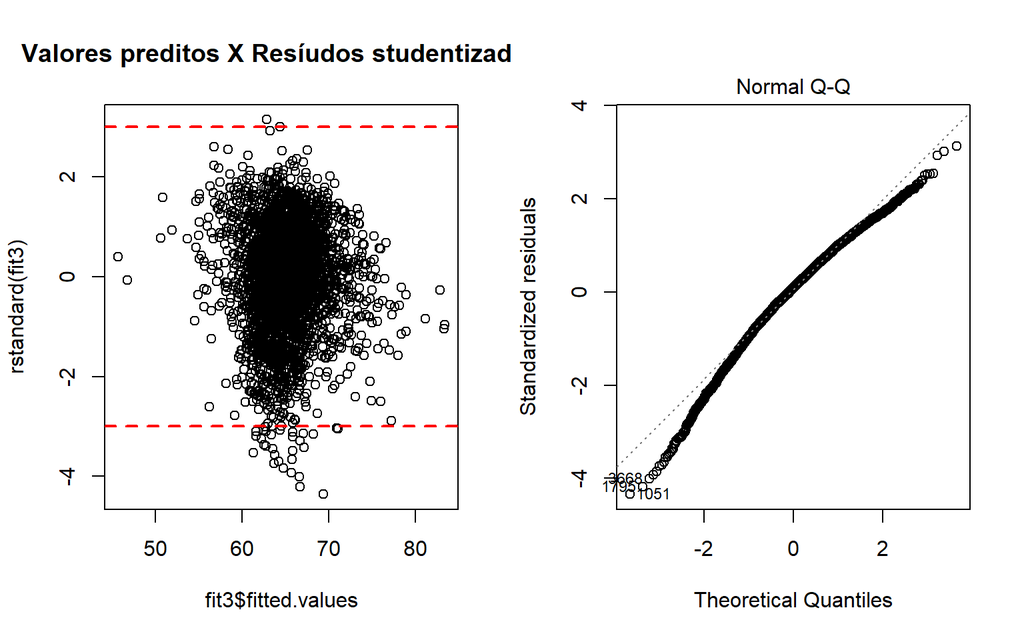

Após realizar um novo modelo, ainda observa-se alguns resíduos que não indicam a não adequação do modelo, mas ainda sim pode-se notar uma pequena melhora no valor do $R^2$ ajustado.

## Modelo de classificação

Baseado nos resultados obtidos no modelo de regressão, o novo banco de dados com as variáveis removidas e pontos discrepantes descartados será utilizado como base para o treinamento de um algoritmo supervisionado para classificação dos filmes.

Como pode-se notar nos valores a seguir, 25% dos filmes presentes no banco de dados possuem uma nota acima de 73. Com isso, esses serão classificados como bons filmes, enquanto os outros serão classificados como maus filmes.

```
##    Min. 1st Qu.  Median    Mean 3rd Qu.    Max.
##   21.00   58.00   66.00   65.09   73.00   97.00
```

Vale ressaltar que, para todos os modelos realizados, a modelagem será feita utilizando 70% dos dados para treino e 30% para teste, além de um cross-validation com 10 grupos.

### Árvore de decisão

Utilizando o pacote `rpart`, será treinado um modelo baseado em um algoritmo de árvore de decisão, a fim de verificar a capacidade de classificar um filme como bom ou não.

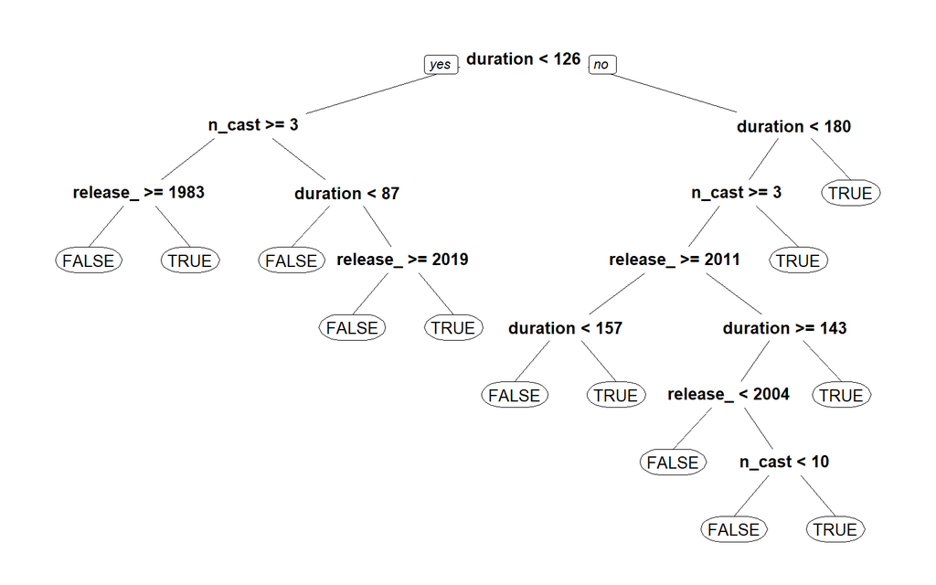

O gráfico acima apresenta a árvore de decisão feita após modelagem, e, após utilizá-la no banco de teste, obteve-se uma área sob a curva ROC de aproximadamente 0.618. Além disso, o modelo apresentou uma acurácia acima de 70%, com especifidade e sensitividade de aproximadamente 0.886 e 0.235, respectivamente. Isto significa que, apesar da acurácia satisfatória, o modelo apresenta dificuldades para prever títulos que serão bem avaliados.

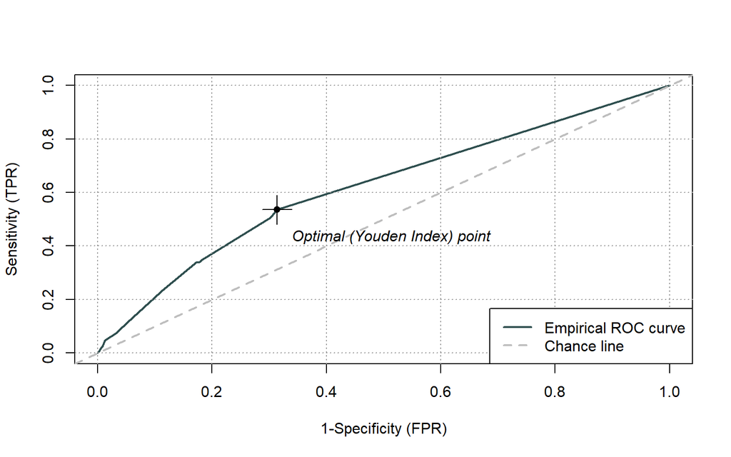

```
## Confusion Matrix and Statistics
##
##           Reference
## Prediction FALSE TRUE
##      FALSE   782  260
##      TRUE    101   80
##
##                Accuracy : 0.7048
##                  95% CI : (0.6784, 0.7303)
##     No Information Rate : 0.722
##     P-Value [Acc > NIR] : 0.9144
##
##                   Kappa : 0.1412
##
##  Mcnemar's Test P-Value : <2e-16
##
##             Sensitivity : 0.23529
##             Specificity : 0.88562
##          Pos Pred Value : 0.44199
##          Neg Pred Value : 0.75048
##              Prevalence : 0.27800
##          Detection Rate : 0.06541
##    Detection Prevalence : 0.14800
##       Balanced Accuracy : 0.56046
##
##        'Positive' Class : TRUE
##
```

### KNN

Utilizando agora o algoritmo KNN para a classificação, obtém-se o seguinte resultado:

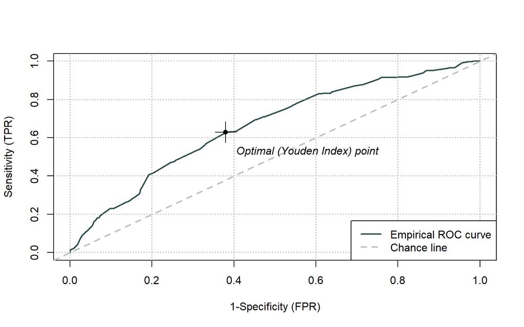

```
## Confusion Matrix and Statistics
##
##           Reference
## Prediction FALSE TRUE
##      FALSE   832  287
##      TRUE     51   53
##
##                Accuracy : 0.7236
##                  95% CI : (0.6976, 0.7485)
##     No Information Rate : 0.722
##     P-Value [Acc > NIR] : 0.4637
##
##                   Kappa : 0.1247
##
##  Mcnemar's Test P-Value : <2e-16
##
##             Sensitivity : 0.15588
##             Specificity : 0.94224
##          Pos Pred Value : 0.50962
##          Neg Pred Value : 0.74352
##              Prevalence : 0.27800
##          Detection Rate : 0.04334
##    Detection Prevalence : 0.08504
##       Balanced Accuracy : 0.54906
##
##        'Positive' Class : TRUE
##
```

Após modelagem, e, após utilizá-la no banco de teste, obteve-se uma área sob a curva ROC de aproximadamente 0.661. Além disso, o modelo apresentou uma acurácia melhor que o modelo anterior, com especifidade e sensitividade de aproximadamente 0.942 e 0.156, respectivamente, ou seja, o novo modelo é melhor que o anterior para prever filmes que não serão bem avaliados, mas ao mesmo tempo apresenta um resultado pior para identificar filmes que realmente serão bem avaliados.

### Conclusões

Após realizar modelagens, obteve-se um modelo com uma acurácia relativamente alta, mas que apresenta problemas para de fato identificar qual filme será bem classificado. Os próximos passos para melhorar o modelo seria uma investigação mais detalhada sobre variáveis como elenco, categorias, e países no qual o filme está disponível. Outra abordagem além de um estudo mais aprofundado sobre as variáveis, seria verificar mais detalhadamente as observações presentes no banco, buscando filtrar outliers ou possíveis pontos discrepantes. Por fim, pode-se buscar algoritmos mais elaborados e comparar o resultado com os modelos já realizados.